# Epic Cosmos vector-borne diseases

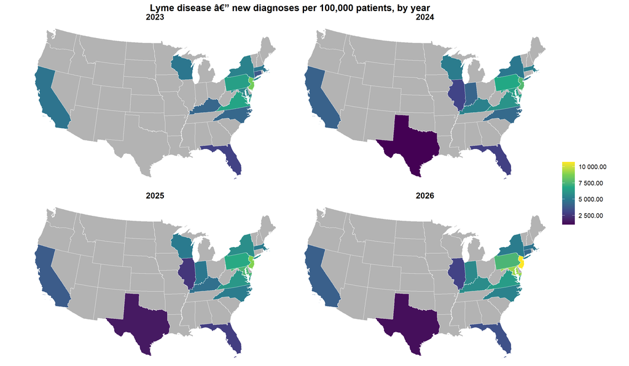

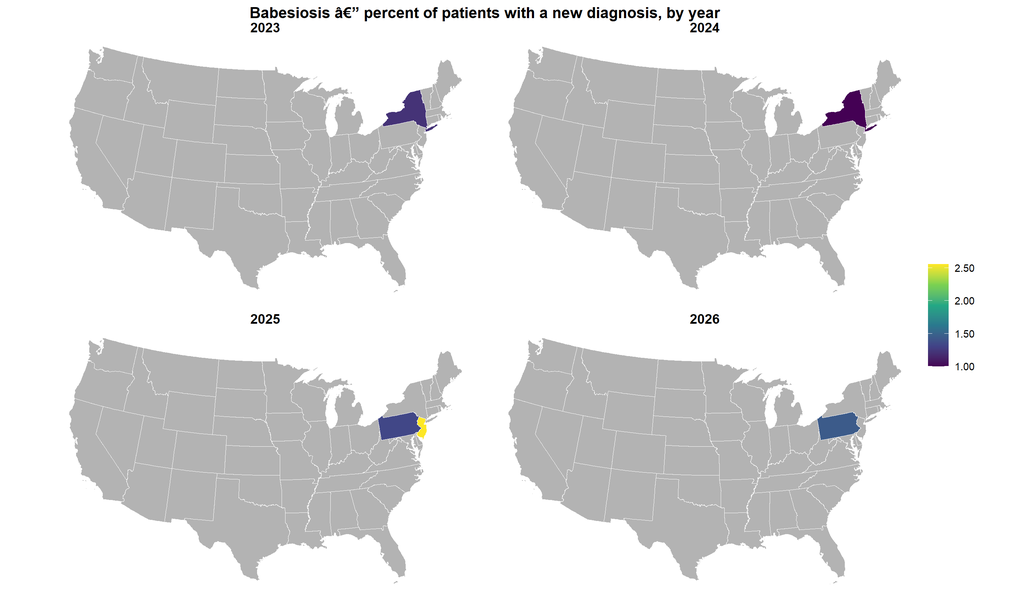

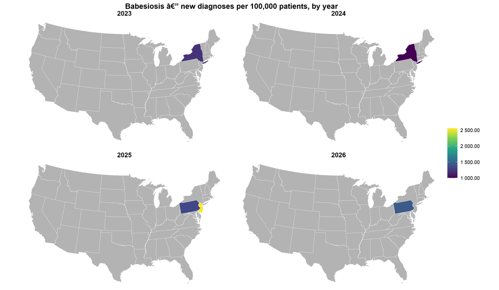

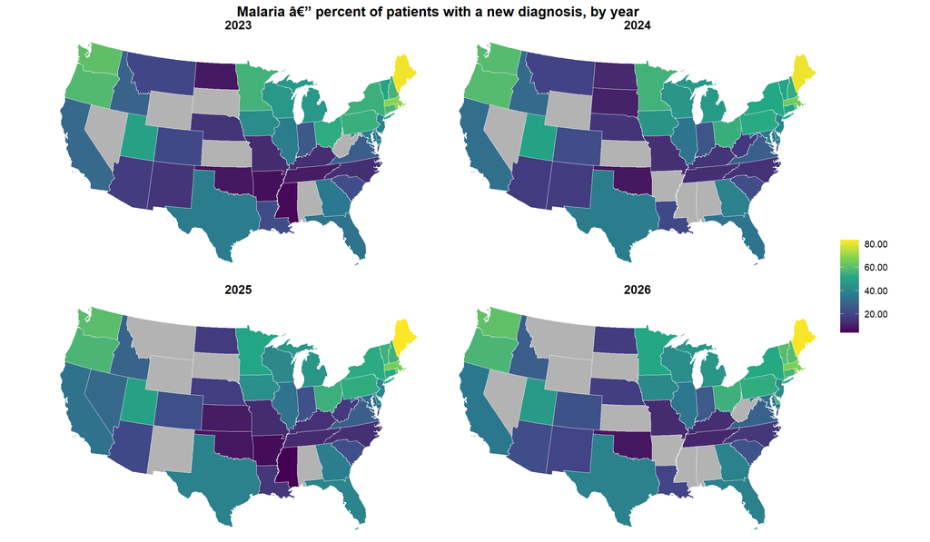

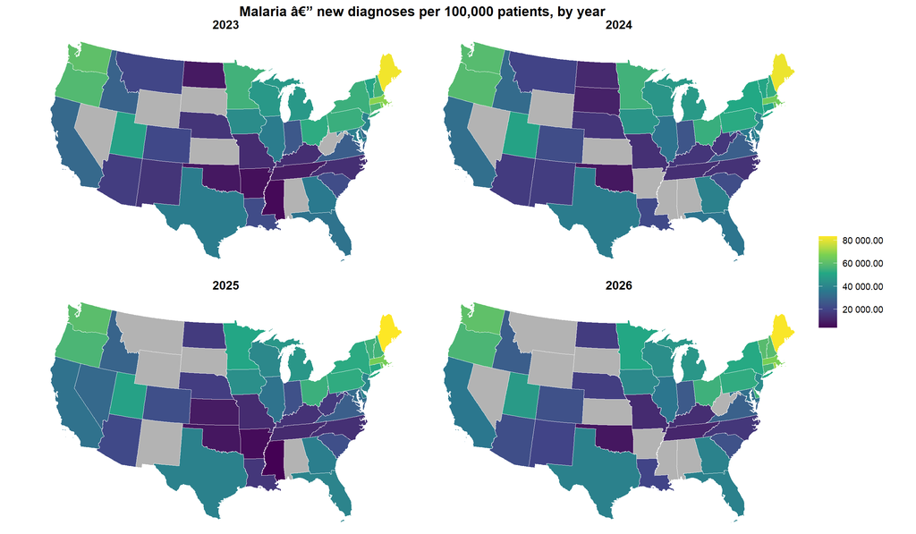

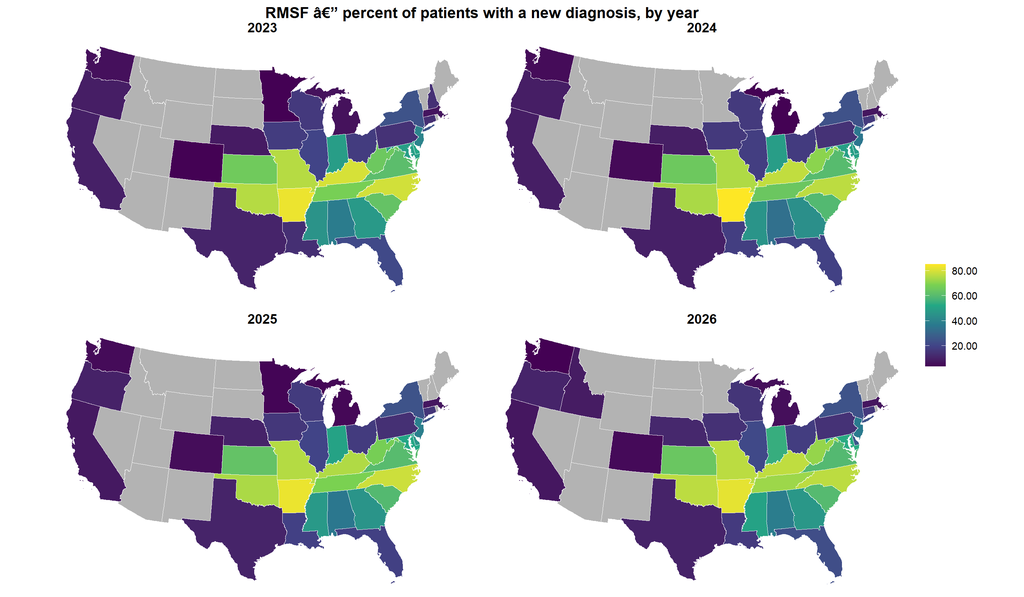

[5 more figures not shown]

## Testing

Lab component results from Epic Cosmos (`standard/data_lab_tests.csv.gz`, monthly). **Testing volume** is the number of disease-specific test results per 100,000 lab component results of any kind (the denominator is results, not patients). **Test positivity** is approximated as new diagnoses (patients, `data_new_cases.csv.gz`) divided by test results (`n new cases / n tests`); the two come from different Cosmos sessions and count different units, so it is a proxy and can exceed what a true per-test positivity would be. There is no Lyme disease test measure. Panels are monthly: national, regional, and state-month.

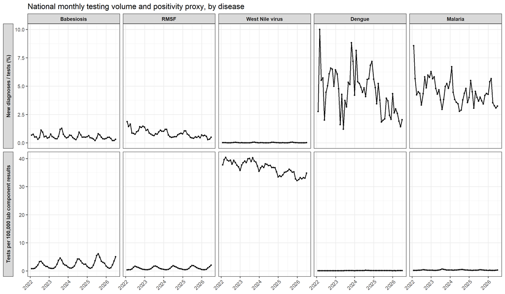

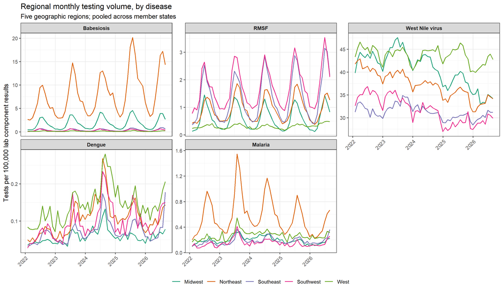

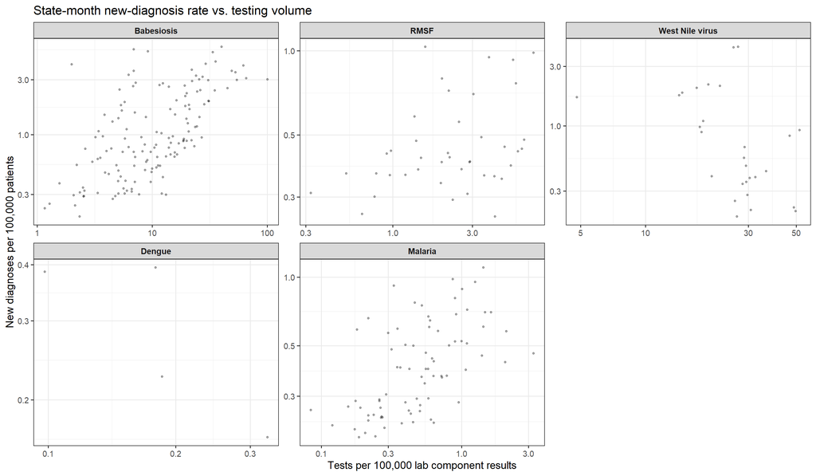

## Comparison with NNDSS and ArboNET

Epic Cosmos counts are compared with the NNDSS and `arbonet`. NNDSS has babesiosis, malaria, West Nile virus and dengue. ArboNET has West Nile virus only.

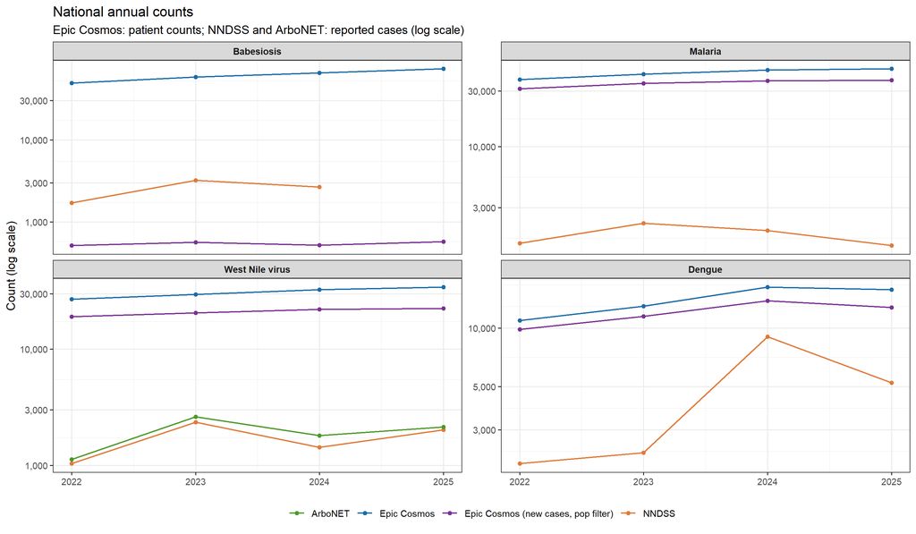

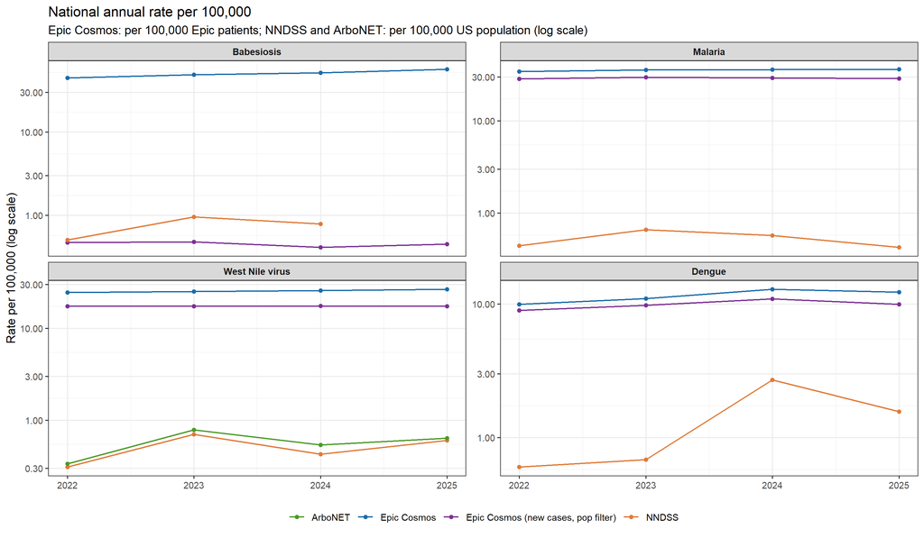

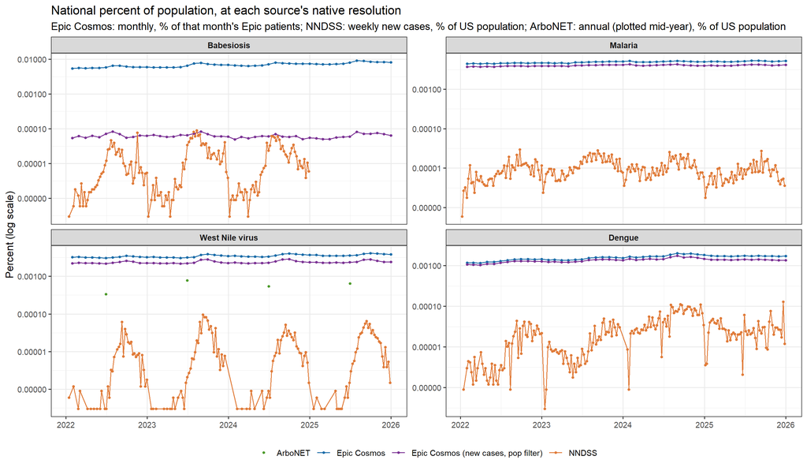

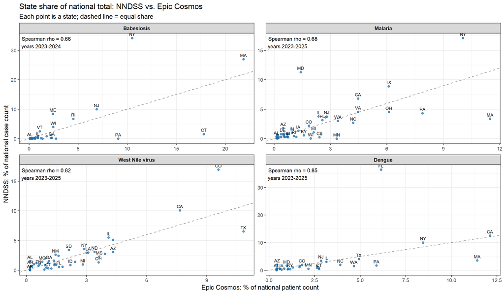

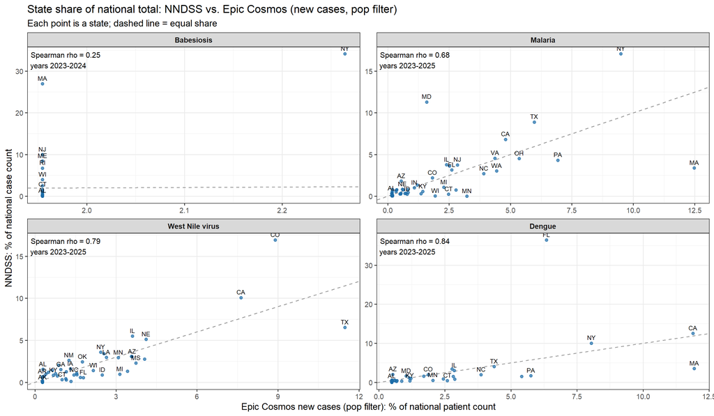

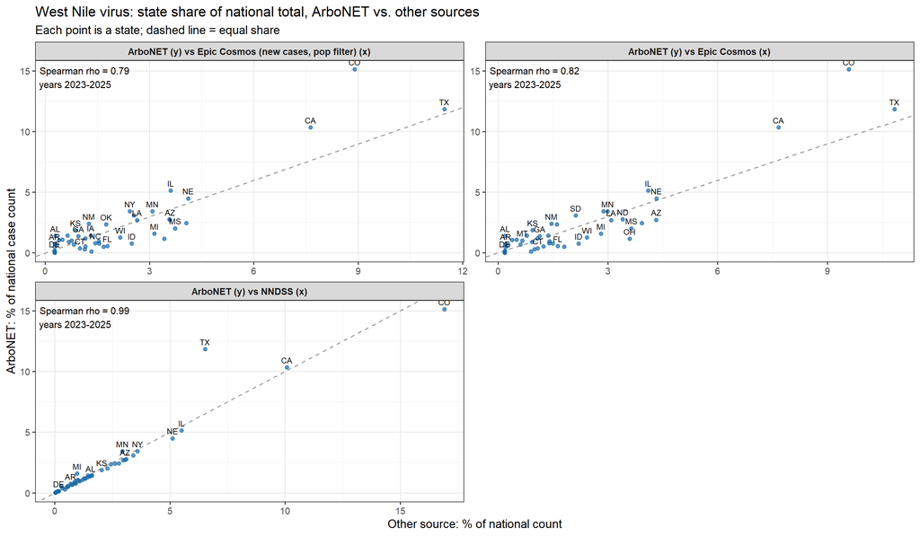

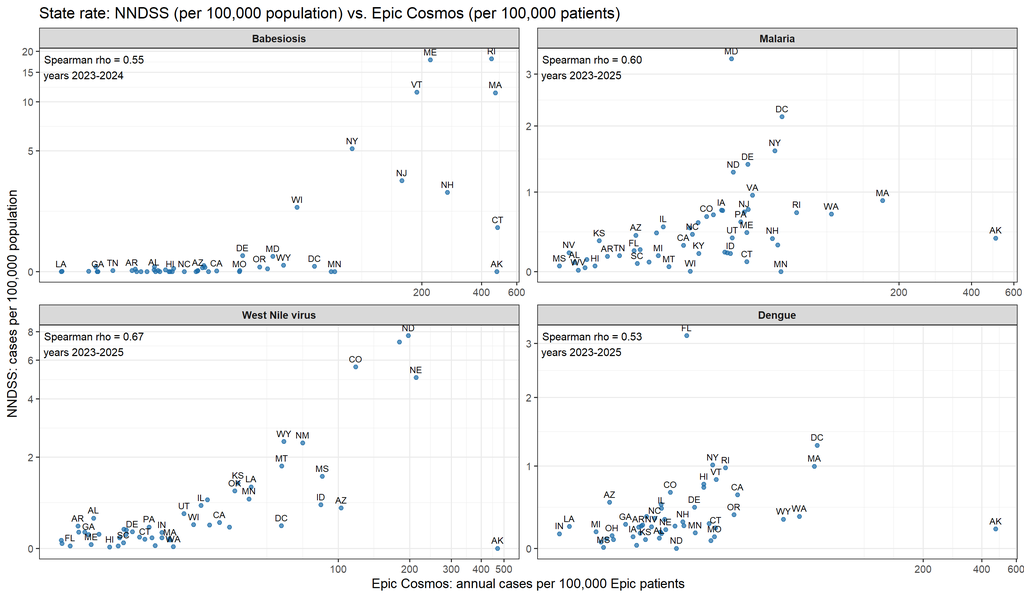

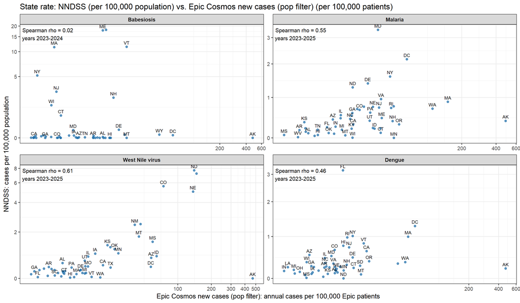

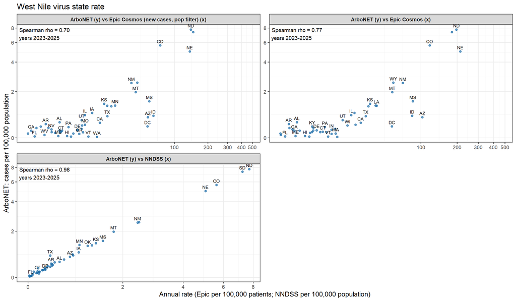